```
<module 'utils.utils' from '/Users/paulius/Docs/Projects/Turing/m2s4/utils/utils.py'>
```

# Analysis of Open Source Mental Illness (OSMI) Survey Data

## Introduction

This analysis explores the OSMI survey dataset, covering years from 2014 to 2019 and focusing on mental health in the tech industry. The dataset consists of three tables: Survey, Question, and Answer, cleaned and manipulated for this study.

## Main Goals

- **Statistical Overview**: Generate a snapshot of the dataset through descriptive statistics.
- **Compare Survey Structure**: Identify changes in survey questions between 2014 and 2019.
- **Analyze Demographics**: Examine the diversity of survey respondents across various factors.
- **Examine Responses**: Evaluate answers to critical survey questions, comparing responses between countries.

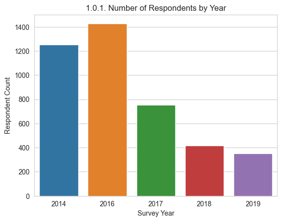

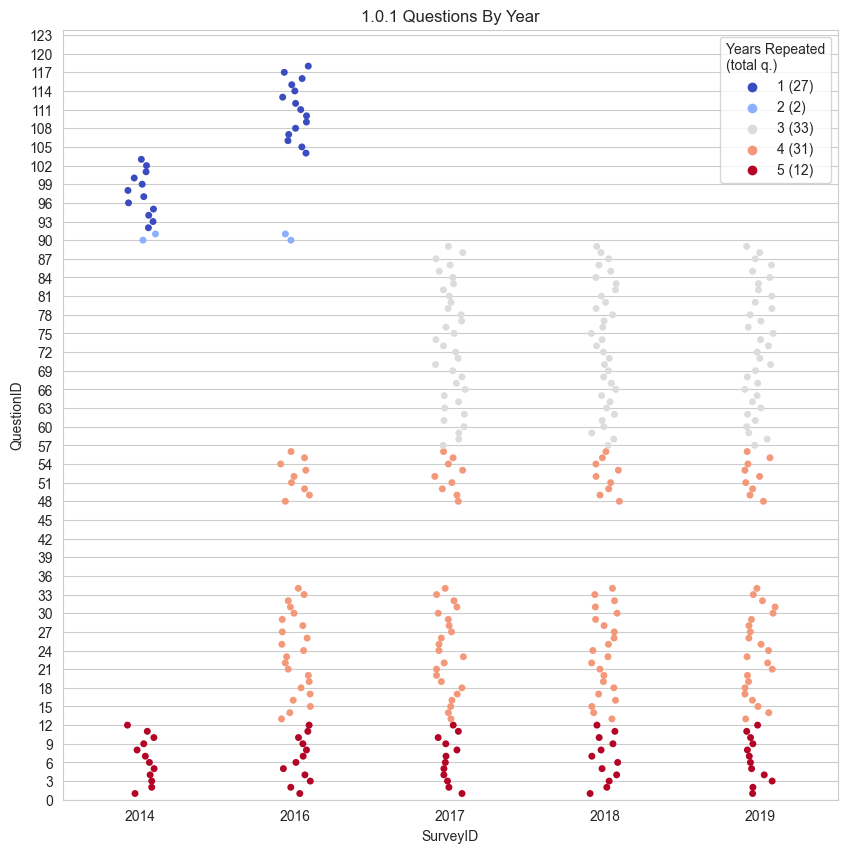

We can see that the structure of the survey has not been consistent over the years. Only a few questions were included in every survey. Most questions asked in 2014 and some in 2016 were not repeated in future surveys. This complicates the analysis because not all answers between different years can be compared and the amount of data which can be analyzed is lower.

However between 2017-2019 all the questions included in surveys were the same.

Questions Included in Survey Every Year

|  | questiontext | questionid |
| --- | --- | --- |
| 0 | What is your age? | 1 |
| 1 | What is your gender? | 2 |
| 2 | What country do you live in? | 3 |
| 3 | If you live in the United States, which state ... | 4 |
| 4 | Are you self-employed? | 5 |
| 5 | Do you have a family history of mental illness? | 6 |
| 6 | Have you ever sought treatment for a mental he... | 7 |
| 7 | How many employees does your company or organi... | 8 |
| 8 | Is your employer primarily a tech company/orga... | 9 |
| 9 | Does your employer provide mental health benef... | 10 |
| 10 | Is your anonymity protected if you choose to t... | 11 |
| 11 | Would you bring up a mental health issue with ... | 12 |

Majority of the questions which were included every year are demographic. However 5 are directly related to the subject matter.

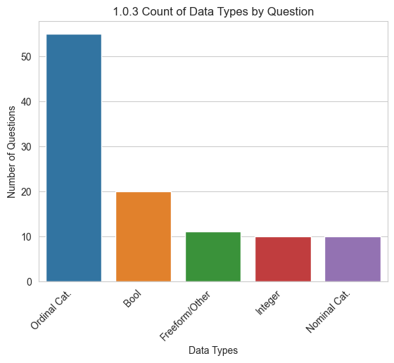

Most questions in the survey have categorical ordinal (ordered) categorical answers, some are freeform (i.e. any text) and these will be excluded from any further analysis because more advanced NLP techniques would be required for that.

One thing that slightly complicates the matter is that even questions which have ordinal answers do not conform to a single scale (e.g. Likert).

Unique categories:

|  | Ordinal Categories | Count |
| --- | --- | --- |
| 0 | (False, Maybe, Some, True) | 27 |
| 1 | (All, None, Some) | 11 |
| 2 | (Always, Never, Often, Rarely, Some) | 4 |
| 3 | (Difficult, Neither easy nor difficult, Somewh... | 2 |
| 4 | (No, because it doesn't matter, No, because it... | 2 |
| 5 | (False, I've always been self-employed, Maybe/... | 2 |
| 6 | (Negatively, No change, Positively) | 2 |
| 7 | (Maybe, No, I don't think it would, No, it has... | 2 |
| 8 | (1-5, 100-500, 26-100, 500-1000, 6-25, More th... | 1 |
| 9 | (Neutral, Not open at all, Somewhat not open, ... | 1 |
| 10 | (1-25%, 26-50%, 51-75%, 76-100%) | 1 |

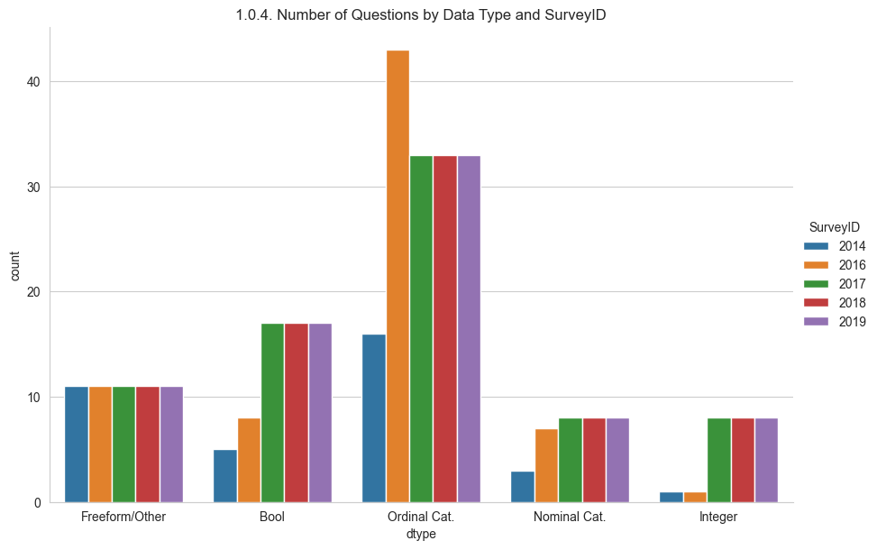

This initial surveys tended to use less questions with boolean, nominal or integer answer. Besides that the types of questions have been mostly consistent.

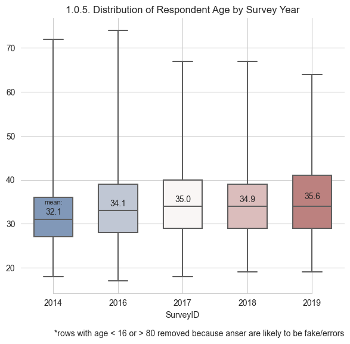

The increasing median age of respondents might indicate the median age of people working in tech might have been increasing over the years. However, this is just speculation since we can't assume that the sample of people participating in the survey is representative of the population.

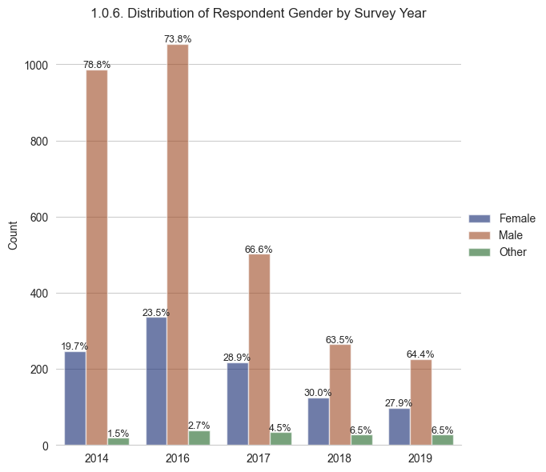

The number of non-male respondents has significantly increased starting in 2017. We can't make any meaningful conclusions just based on this either without knowing how representative the survey is.

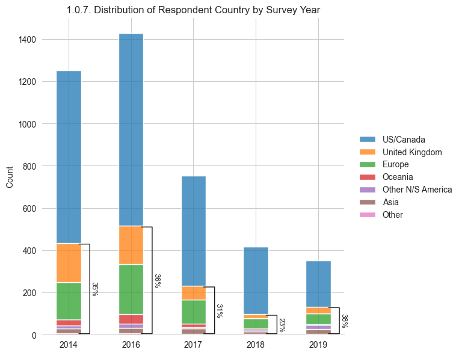

The overwhelming majority of respondents work in US or Canada. The number of respondents in UK has been high in the initial years but have decreases significantly as the total number of respondents has decreased as well over the last few years.

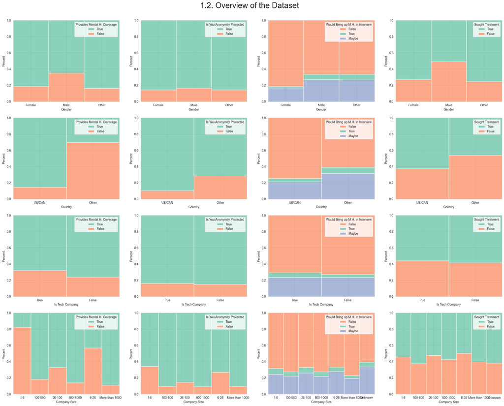

Looking at the summary of some of the main questions which were included in the survey every year we can see that:

- Companies where males are overrepresented seem to provide mental health coverage less often.
- Relatively few companies outside the US and Canada seem to provide metal health coverage (answer might not be comparable due to differences in healthcare systems and insurance models)
- Americans are more likely to believe that their anonymity is protected when responding to the survey.
- Workers in US/CAN are likely to have sought treatment but are less likely to discuss this in interviews.

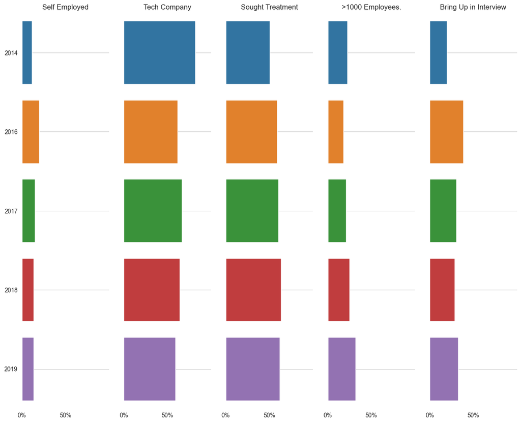

Self-Employed: The proportion increased significantly in 2016 (20%) compared to 2014 (11.3%), and then stabilized around 13-14% for subsequent years.

Tech Company: There's a general decline in the proportion of respondents from tech companies, dropping from 81.9% in 2014 to 59% in 2019.

Brought Up Mental Health in Interview: This saw an increase over the years, moving from 19.8% in 2014 to 32.5% in 2019.

```
SurveyID
2016    1429
2017     754
2018     417
2019     351
Name: count, dtype: int64
```

```
'Pairs of Variables With Highest Correlation'
```

|  | Var1 | Var1_type | Var2 | Var2_type | Correlation | AbsCorrelation |
| --- | --- | --- | --- | --- | --- | --- |
| 1539 | If you have been diagnosed or treated for a mental health disorder, do you ever reveal this to clients or business contacts? | Ordinal | If you have been diagnosed or treated for a mental health disorder, do you ever reveal this to coworkers or employees? | Ordinal | 0.778778 | 0.778778 |
| 1303 | Have you ever been diagnosed with a mental health disorder? | boolean | Have you ever sought treatment for a mental health disorder from a mental health professional? | boolean | 0.745792 | 0.745792 |
| 1375 | If you have a mental health disorder, how often do you feel that it interferes with your work when being treated effectively? | Ordinal | If you have a mental health disorder, how often do you feel that it interferes with your work when not being treated effectively (i.e., when you are experiencing symptoms)? | Ordinal | 0.736218 | 0.736218 |
| 1287 | Do you currently have a mental health disorder? | Ordinal | Have you ever been diagnosed with a mental health disorder? | Ordinal | 0.732858 | 0.732858 |
| 1328 | Have you ever been diagnosed with a mental health disorder? | boolean | Have you had a mental health disorder in the past? | boolean | 0.716835 | 0.716835 |
| 1289 | Do you currently have a mental health disorder? | Ordinal | If you have a mental health disorder, how often do you feel that it interferes with your work when not being treated effectively (i.e., when you are experiencing symptoms)? | Ordinal | 0.710354 | 0.710354 |
| 852 | Have your previous employers provided mental health benefits? | Ordinal | Were you aware of the options for mental health care provided by your previous employers? | Ordinal | 0.685679 | 0.685679 |
| 276 | Have you ever sought treatment for a mental health disorder from a mental health professional? | boolean | Have you had a mental health disorder in the past? | boolean | 0.682203 | 0.682203 |
| 1285 | Do you currently have a mental health disorder? | Ordinal | Have you had a mental health disorder in the past? | Ordinal | 0.660385 | 0.660385 |
| 1332 | Have you ever been diagnosed with a mental health disorder? | boolean | If you have a mental health disorder, how often do you feel that it interferes with your work when not being treated effectively (i.e., when you are experiencing symptoms)? | boolean | 0.634628 | 0.634628 |
| 1246 | Have you had a mental health disorder in the past? | Ordinal | If you have a mental health disorder, how often do you feel that it interferes with your work when not being treated effectively (i.e., when you are experiencing symptoms)? | Ordinal | 0.633507 | 0.633507 |
| 280 | Have you ever sought treatment for a mental health disorder from a mental health professional? | boolean | If you have a mental health disorder, how often do you feel that it interferes with your work when not being treated effectively (i.e., when you are experiencing symptoms)? | boolean | 0.621142 | 0.621142 |
| 166 | If you live in the United States, which state or territory do you live in? | Nominal | What US state or territory do you work in? | Nominal | 0.617408 | 0.617408 |
| 1260 | Do you currently have a mental health disorder? | Ordinal | Have you ever sought treatment for a mental health disorder from a mental health professional? | Ordinal | 0.608312 | 0.608312 |
| 1288 | Do you currently have a mental health disorder? | Ordinal | If you have a mental health disorder, how often do you feel that it interferes with your work when being treated effectively? | Ordinal | 0.607989 | 0.607989 |
| 1335 | Have you ever been diagnosed with a mental health disorder? | boolean | If you have been diagnosed or treated for a mental health disorder, do you ever reveal this to clients or business contacts? | boolean | 0.60321 | 0.60321 |
| 1331 | Have you ever been diagnosed with a mental health disorder? | boolean | If you have a mental health disorder, how often do you feel that it interferes with your work when being treated effectively? | boolean | 0.602417 | 0.602417 |
| 1336 | Have you ever been diagnosed with a mental health disorder? | boolean | If you have been diagnosed or treated for a mental health disorder, do you ever reveal this to coworkers or employees? | boolean | 0.600661 | 0.600661 |
| 279 | Have you ever sought treatment for a mental health disorder from a mental health professional? | boolean | If you have a mental health disorder, how often do you feel that it interferes with your work when being treated effectively? | boolean | 0.586942 | 0.586942 |
| 1250 | Have you had a mental health disorder in the past? | Ordinal | If you have been diagnosed or treated for a mental health disorder, do you ever reveal this to coworkers or employees? | Ordinal | 0.582787 | 0.582787 |
| 1293 | Do you currently have a mental health disorder? | Ordinal | If you have been diagnosed or treated for a mental health disorder, do you ever reveal this to coworkers or employees? | Ordinal | 0.577509 | 0.577509 |
| 1245 | Have you had a mental health disorder in the past? | Ordinal | If you have a mental health disorder, how often do you feel that it interferes with your work when being treated effectively? | Ordinal | 0.566616 | 0.566616 |
| 1249 | Have you had a mental health disorder in the past? | Ordinal | If you have been diagnosed or treated for a mental health disorder, do you ever reveal this to clients or business contacts? | Ordinal | 0.558548 | 0.558548 |
| 1378 | If you have a mental health disorder, how often do you feel that it interferes with your work when being treated effectively? | Ordinal | If you have been diagnosed or treated for a mental health disorder, do you ever reveal this to clients or business contacts? | Ordinal | 0.548485 | 0.548485 |
| 676 | Would you feel comfortable discussing a mental health issue with your coworkers? | Ordinal | Would you feel comfortable discussing a mental health issue with your direct supervisor(s)? | Ordinal | 0.546945 | 0.546945 |
| 1292 | Do you currently have a mental health disorder? | Ordinal | If you have been diagnosed or treated for a mental health disorder, do you ever reveal this to clients or business contacts? | Ordinal | 0.533744 | 0.533744 |
| 284 | Have you ever sought treatment for a mental health disorder from a mental health professional? | boolean | If you have been diagnosed or treated for a mental health disorder, do you ever reveal this to coworkers or employees? | boolean | 0.52714 | 0.52714 |
| 1379 | If you have a mental health disorder, how often do you feel that it interferes with your work when being treated effectively? | Ordinal | If you have been diagnosed or treated for a mental health disorder, do you ever reveal this to coworkers or employees? | Ordinal | 0.519316 | 0.519316 |
| 1421 | If you have a mental health disorder, how often do you feel that it interferes with your work when not being treated effectively (i.e., when you are experiencing symptoms)? | Ordinal | If you have been diagnosed or treated for a mental health disorder, do you ever reveal this to clients or business contacts? | Ordinal | 0.515026 | 0.515026 |
| 283 | Have you ever sought treatment for a mental health disorder from a mental health professional? | boolean | If you have been diagnosed or treated for a mental health disorder, do you ever reveal this to clients or business contacts? | boolean | 0.513596 | 0.513596 |
| 938 | Did your previous employers ever formally discuss mental health (as part of a wellness campaign or other official communication)? | Ordinal | Did your previous employers provide resources to learn more about mental health disorders and how to seek help? | Ordinal | 0.510898 | 0.510898 |
| 1597 | Do you believe your productivity is ever affected by a mental health issue? | Ordinal | If you have a mental health disorder, how often do you feel that it interferes with your work when not being treated effectively (i.e., when you are experiencing symptoms)? | Ordinal | 0.508203 | 0.508203 |
| 523 | Do you know the options for mental health care available under your employer-provided health coverage? | Ordinal | Does your employer provide mental health benefits as part of healthcare coverage? | Ordinal | 0.503879 | 0.503879 |
| 1422 | If you have a mental health disorder, how often do you feel that it interferes with your work when not being treated effectively (i.e., when you are experiencing symptoms)? | Ordinal | If you have been diagnosed or treated for a mental health disorder, do you ever reveal this to coworkers or employees? | Ordinal | 0.500585 | 0.500585 |
| 1093 | Would you be willing to bring up a physical health issue with a potential employer in an interview? | Ordinal | Would you bring up a mental health issue with a potential employer in an interview? | Ordinal | 0.463834 | 0.463834 |
| 1297 | Have you ever been diagnosed with a mental health disorder? | boolean | SurveyID | boolean | 0.457883 | 0.457883 |
| 1593 | Do you believe your productivity is ever affected by a mental health issue? | Ordinal | Have you had a mental health disorder in the past? | Ordinal | 0.449269 | 0.449269 |
| 1594 | Do you believe your productivity is ever affected by a mental health issue? | Ordinal | Do you currently have a mental health disorder? | Ordinal | 0.446674 | 0.446674 |
| 978 | Did your previous employers provide resources to learn more about mental health disorders and how to seek help? | Ordinal | Were you aware of the options for mental health care provided by your previous employers? | Ordinal | 0.446021 | 0.446021 |
| 1595 | Do you believe your productivity is ever affected by a mental health issue? | Ordinal | Have you ever been diagnosed with a mental health disorder? | Ordinal | 0.432636 | 0.432636 |
| 1596 | Do you believe your productivity is ever affected by a mental health issue? | Ordinal | If you have a mental health disorder, how often do you feel that it interferes with your work when being treated effectively? | Ordinal | 0.431468 | 0.431468 |
| 977 | Did your previous employers provide resources to learn more about mental health disorders and how to seek help? | Ordinal | Have your previous employers provided mental health benefits? | Ordinal | 0.426946 | 0.426946 |
| 1579 | Do you believe your productivity is ever affected by a mental health issue? | Ordinal | Have you ever sought treatment for a mental health disorder from a mental health professional? | Ordinal | 0.418791 | 0.418791 |
| 1601 | Do you believe your productivity is ever affected by a mental health issue? | Ordinal | If you have been diagnosed or treated for a mental health disorder, do you ever reveal this to coworkers or employees? | Ordinal | 0.400355 | 0.400355 |
| 1600 | Do you believe your productivity is ever affected by a mental health issue? | Ordinal | If you have been diagnosed or treated for a mental health disorder, do you ever reveal this to clients or business contacts? | Ordinal | 0.392196 | 0.392196 |
| 935 | Did your previous employers ever formally discuss mental health (as part of a wellness campaign or other official communication)? | Ordinal | Have your previous employers provided mental health benefits? | Ordinal | 0.374845 | 0.374845 |
| 936 | Did your previous employers ever formally discuss mental health (as part of a wellness campaign or other official communication)? | Ordinal | Were you aware of the options for mental health care provided by your previous employers? | Ordinal | 0.370138 | 0.370138 |
| 600 | Does your employer offer resources to learn more about mental health disorders and options for seeking help? | Ordinal | Has your employer ever formally discussed mental health (for example, as part of a wellness campaign or other official communication)? | Ordinal | 0.365938 | 0.365938 |
| 1020 | Was your anonymity protected if you chose to take advantage of mental health or substance abuse treatment resources with previous employers? | Ordinal | Were you aware of the options for mental health care provided by your previous employers? | Ordinal | 0.360805 | 0.360805 |
| 981 | Did your previous employers provide resources to learn more about mental health disorders and how to seek help? | Ordinal | Was your anonymity protected if you chose to take advantage of mental health or substance abuse treatment resources with previous employers? | Ordinal | 0.353717 | 0.353717 |

### Question Analysis

The charts below show the relationships some selected answers have with the main demographic variables and their correlations to the other question in the survey (if coefficient is above 0.25).

The answers were selected from all the questions which were available in every survey between 2016 and 2019 based on their subjectively perceived importance and the number of other questions they correlate with.

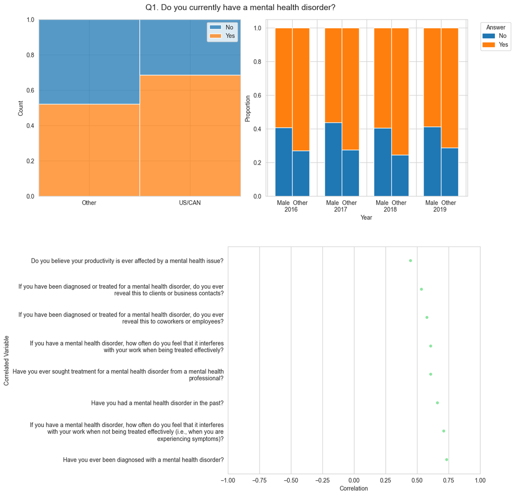

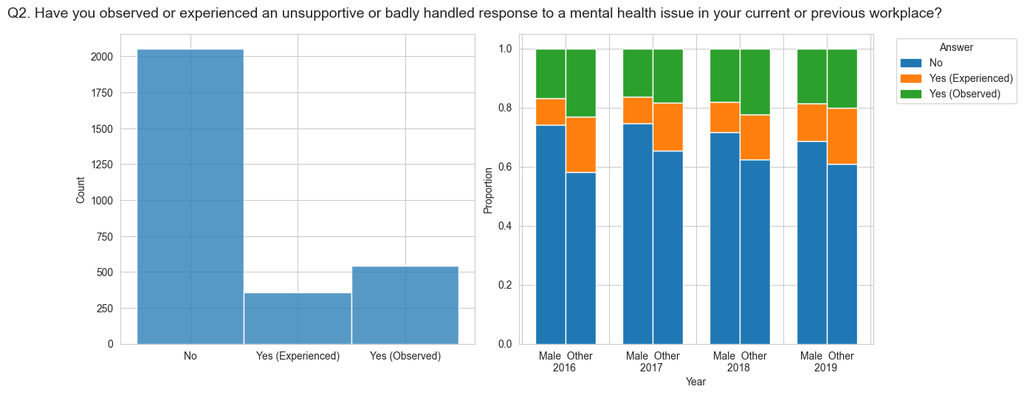

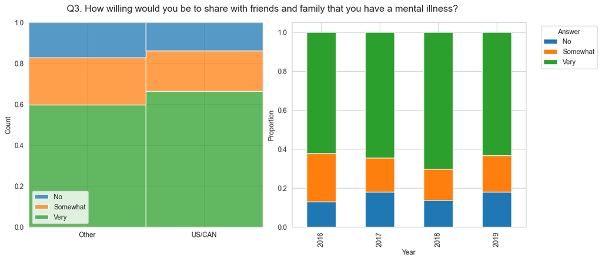

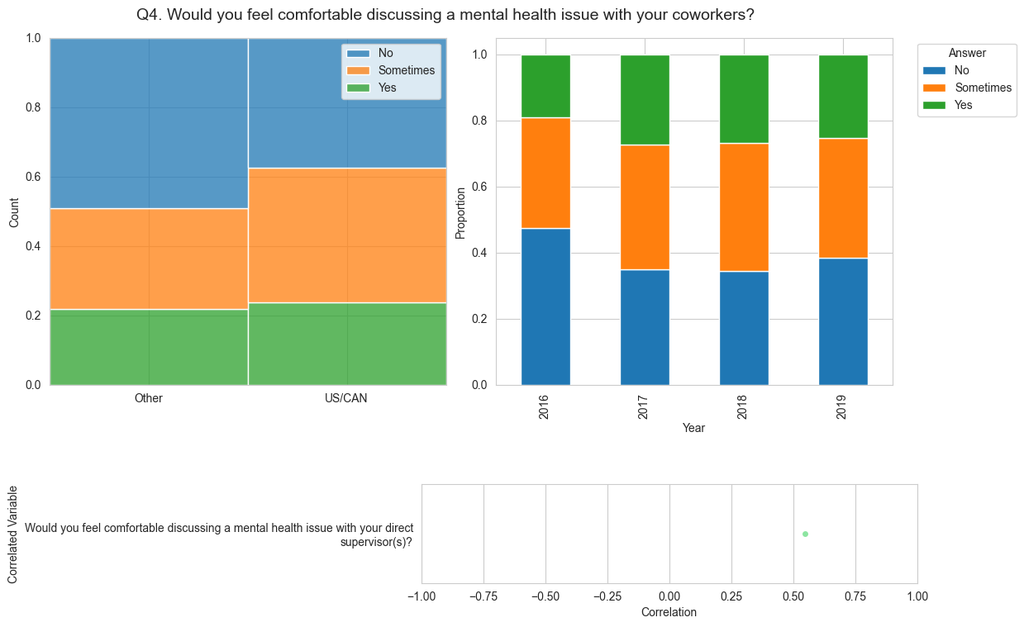

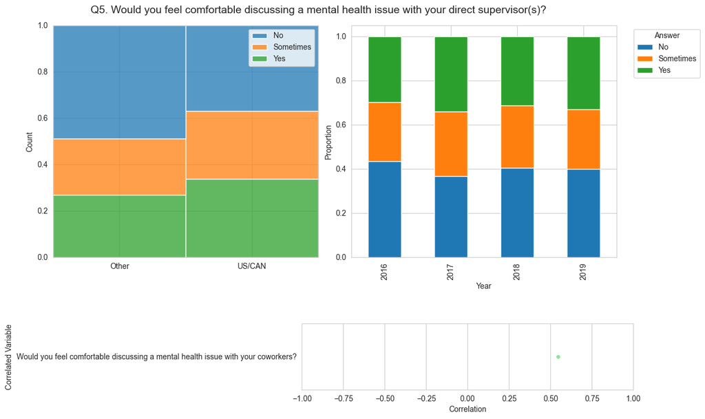

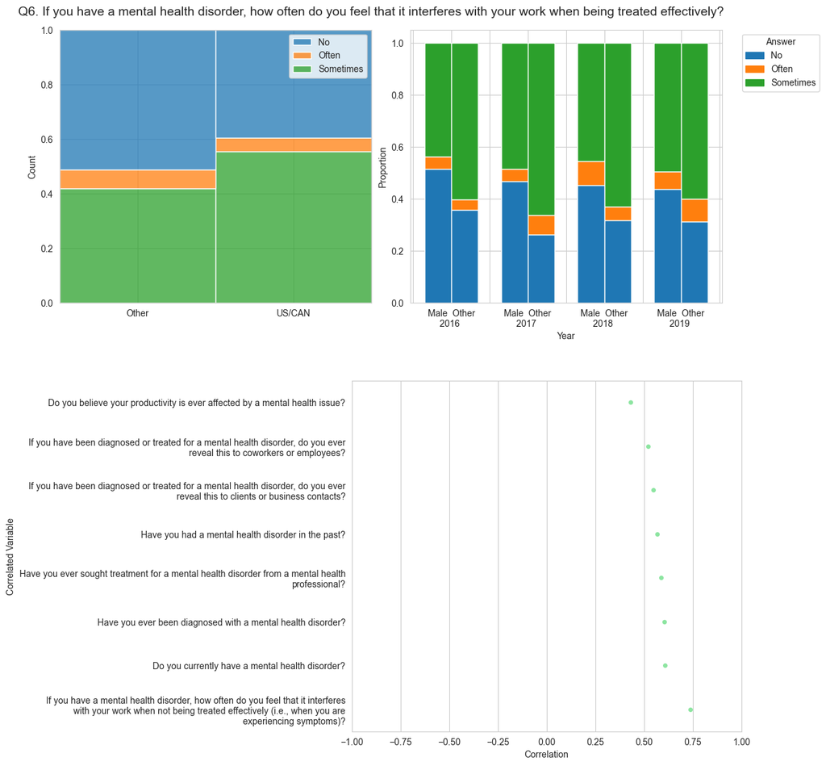

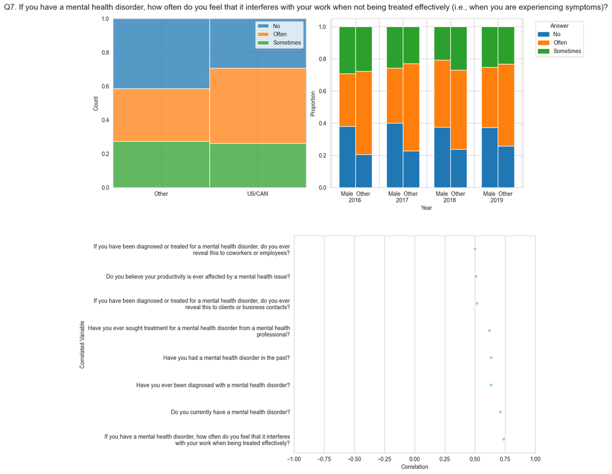

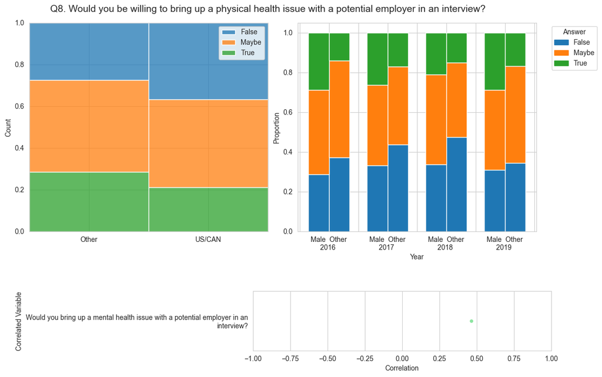

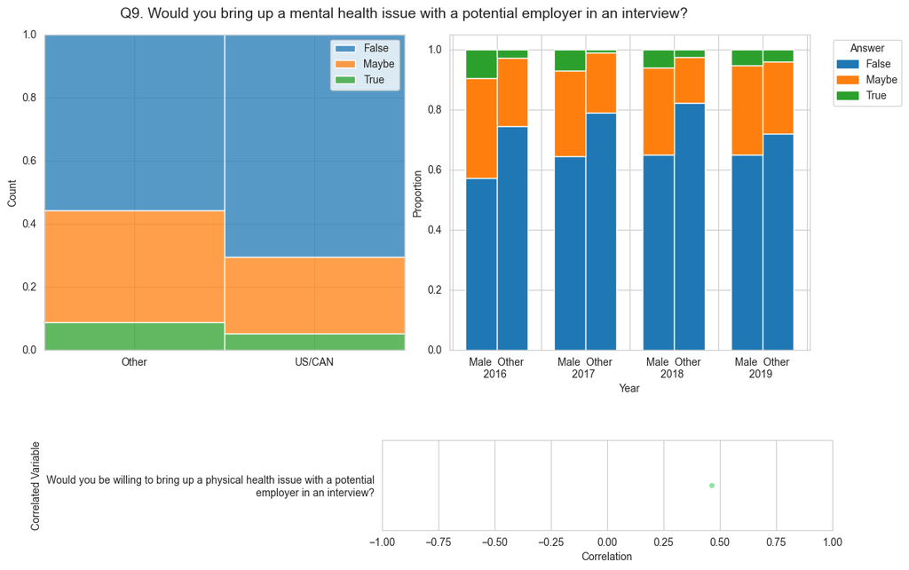

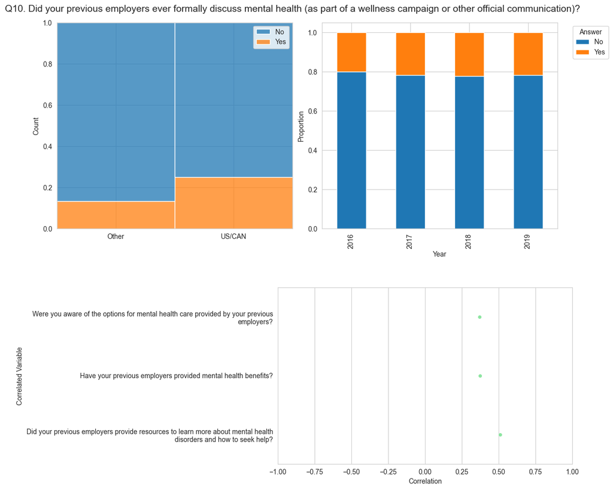

##### Limitations

In addition, there are several issues with the analysis itself which could be addressed in the future:

- Because the sample of the population participating in the survey is likely highly unrepresentative it would be a good idea to apply weighting techniques to the analysis. Both to adjust between demographic differences between different years (.e.g more workers in early surveys worked in tech companies, the composition of countries differed etc.) and adjust it based on the overal population (by using additional datasets).
- Most of the focus has been on a set of arbitrarily selected questions. We should utilize more advanced techniques like clustering and PCA to include a higher number of questions in the analysis. That would also help us get a clearer picture on their relationships). Additionally, it might make sense to consider building a multiple regression or other model to determine the statistical significant of different questions (we would need to select a target variable (or multiple ones) for that which might be tricky given the nature of the survey).
- The associated paper and other metadata should've been analyzed deeper before doing this analysis.